# State Political Affiliation and Hate Crime

## *5 Discussion/analysis*

In our study, there were confounding variables that impacted our results. As shown in the DAG below, the two main confounding variables are non-voters and underreporting of crimes.

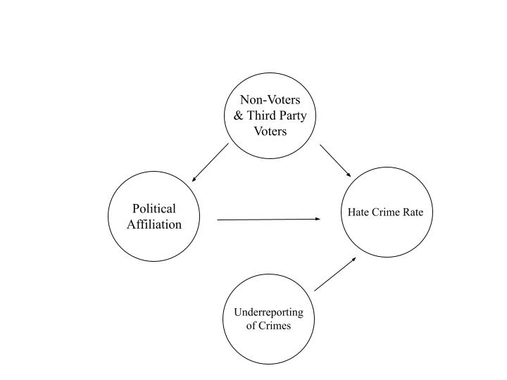

DAG

Non-voters impacted our data in multiple ways. When we did our analysis and EDA, we only looked at members of the electorate who voted for the Republican and Democratic parties. We only performed our analysis using the percentage of Republican voters in the 2020 election. This means our analysis did not take into account constituents who voted for alternate parties. There were over 2,000,000 votes for third party and write in candidates (FEC, 2021). Additionally, we did not account for non-voters in the U.S. Only 67% of eligible voters casted a ballot in the 2020 election (Fabina, 2021). We did not take into account residents and others who cannot vote.

As mentioned above, reporting to the UCR is voluntary. More importantly, there is a large hate crime reporting gap (COPS Office, 2013). This works in many ways. First: surveys done by the US Department of Justice have uncovered that many people who are victims of hate crimes do not report. According to the DOJ, victims do not believe they will be aided by law enforcement. Additionally, many crimes that are motivated by hate are not reported as such, as it is difficult for officers to discern whether a crime is motivated by hate. It is also much more work to convict and prove a crime was motivated by hate (Davis, 2021). According to the International Association of Police Chiefs, less than ⅔ of the over 250,000 hate crimes committed per year are reported (Davis, 2021).

In the future research, we would look more closely at the gaps in hate crime reporting. Rather than analyzing the hate crime data, we would analyze the connection between states that voted majority Republican and the percentage of jurisdictions that reported. We would utilize linear regression again to establish if there is a causal relationship. A diff-in-diff model could also be interesting to analyze the “Trump Effect” on hate crime rates, but existing data might be insufficient for that.

## *6 Bibliography*

COPS Office. (2013, May). Hate Crime Reporting – Working to Close the Gap. Retrieved from https://cops.usdoj.gov/html/dispatch/05-2013/hate_crime_reporting.asp

Davis, R. L. (2021). The Hate Crimes Reporting Gap: Low Numbers Keep Tensions High  
Retrieved from https://www.policechiefmagazine.org/the-hate-crimes/

Fabina, J. (2021, April 29). Despite pandemic challenges, 2020 election had largest increase in voting between presidential elections on record. Retrieved from https://www.census.gov/library/stories/2021/04/record-high-turnout-in-2020-general-elec tion.html

Federal Bureau of Investigation. (2019, October 29). Incidents and offenses. Retrieved from https://ucr.fbi.gov/hate-crime/2019/topic-pages/incidents-and-offenses

Federal Election Commission. (2021, January 28). Official 2020 presidential general election results. Retrieved from https://www.fec.gov/resources/cms-content/documents/2020presgeresults.pdf

Rushin, S., & Edwards, G. S. (2018). The effect of president Trump’s election on hate crimes. SSRN Electronic Journal. https://doi.org/10.2139/ssrn.3102652

Schaffner, B. F., Macwilliams, M., & Nteta, T. (2018). Understanding white polarization in the 2016 vote for president: The sobering role of racism and sexism. Political Science Quarterly, 133(1), 9–34. https://doi.org/10.1002/polq.12737

Villarreal, D. (2020, November 17). Hate crimes under Trump surged nearly 20 percent says FBI report. Newsweek. Retrieved December 12, 2021, from https://www.newsweek.com/hate-crimes-under-trump-surged-nearly-20-percent-says-fbi-report-1547870.